# Selection

## 3.5 Analyze results

### 3.5.1 Bulbul

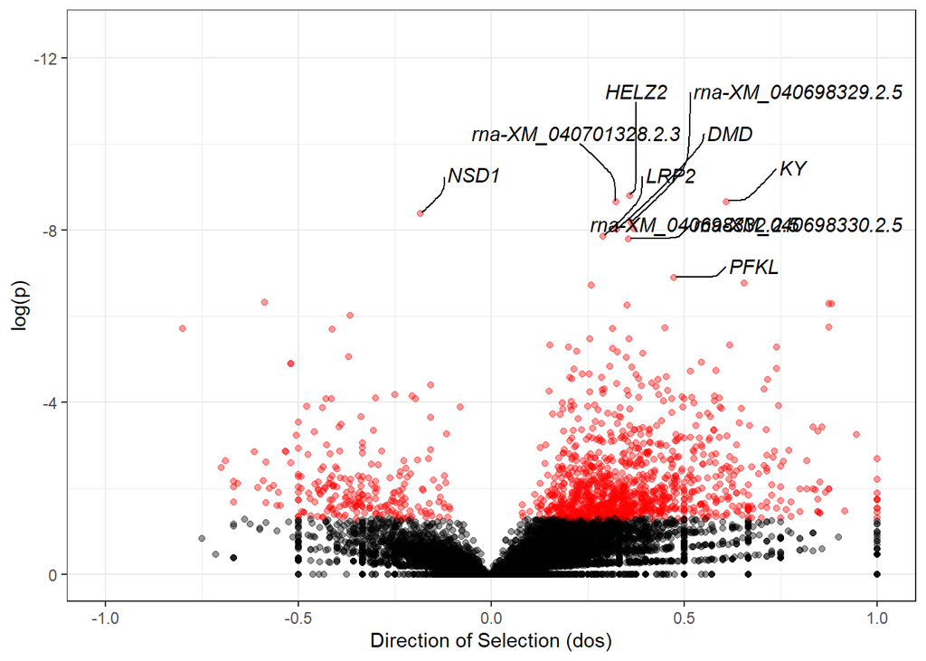

```r
bulbul_selected <- subset(trans_largest, transcript %in% mk_table_largest$transcript[which(mk_table_largest$sig %in% "red" & mk_table_largest$imp.dos > 0)])

library(rbioapi)
bulbul_enrich <- rba_panther_enrich(genes = unique(bulbul_selected$gene),
                                 organism = 9031,
                                 annot_dataset = "GO:0008150",
                                 ref_genes = unique(mk_table_largest$gene),
                                 ref_organism = 9031)

write.table(unique(bulbul_selected$gene), "bulbul_selected_mk.txt", quote = F, sep = "", eol = ",", row.names = F, col.names = F)
write.table(unique(trans$gene), "bulbul_all_genes_mk.txt", quote = F, sep = "", row.names = F, col.names = F)
write.table(bulbul_enrich$result, "bulbul_all_enrichment_mk.txt", quote = F, sep = "\t", row.names = F, col.names = F)
```

### 3.5.2 Swallow

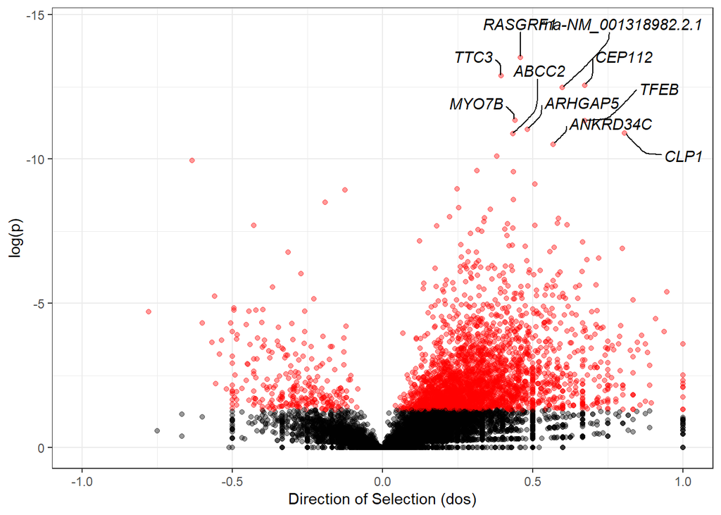

```r
swallow_selected <- subset(trans_largest, transcript %in% mk_table_largest$transcript[which(mk_table_largest$sig %in% "red" & mk_table_largest$imp.dos > 0)])

swallow_enrich <- rba_panther_enrich(genes = unique(swallow_selected$gene),
                                 organism = 9031,
                                 annot_dataset = "GO:0008150",
                                 ref_genes = unique(mk_table_largest$gene),
                                 ref_organism = 9031)

write.table(unique(swallow_selected$gene), "swallow_selected_mk.txt", quote = F, sep = "", eol = ",", row.names = F, col.names = F)
write.table(unique(trans$gene), "swallow_all_genes_mk.txt", quote = F, sep = "", row.names = F, col.names = F)
write.table(swallow_enrich$result, "swallow_all_enrichment_mk.txt", quote = F, sep = "\t", row.names = F, col.names = F)
```

```r
bs_overlap <- unique(intersect(bulbul_selected$gene, swallow_selected$gene))
phyper(length(bs_overlap)-1,1069,15259-2584,2584)

absrel_bulbul_overlap <- unique(intersect(bulbul_selected$gene, sel_out_targets$gene[which(sel_out_targets$bulbul>0)]))
absrel_swallow_overlap <- unique(intersect(swallow_selected$gene, sel_out_targets$gene[which(sel_out_targets$swallow>0)]))
```

# 4 Modified MK Test

We used a modified version of the MK test comparing fixed and polymorphic sites in each CNEE to synonymous sites in the gene. The same vcf files from above were used in the analysis.

## 4.1 Counting sites in elements

We used a custom python script to count the fixed and polymorphic sites in all elements using the vcf files for bulbuls and swallow respectively

```python
import pandas as pd
import pysam
import argparse,sys,os
import glob

def get_fix_poly(vcf, scaffold, start, stop):
    samples = list((vcf.header.samples))
    fix = 0
    poly = 0
    for rec in vcf.fetch(scaffold, start, stop):
        out = False
        alt = 0
        tot = 0
        #Uses same filters as those implemented in degenotate for outgroups
        if (rec.samples[samples[-2]]['GT'] == (1,1) and rec.samples[samples[-1]]['GT'] == (1,1)):
            out = True
        for sample in samples[:-2]:
            for haplotype in rec.samples[sample]['GT']:
                if haplotype == 1:
                    alt += 1
                    tot += 1
                elif haplotype == 0:
                    tot += 1
        #Using an allele frequency cutoff of 1/number of samples.
        af = alt/tot
        if ((af < (1/len(samples))) and out):
            fix += 1
        elif ((af < (1/len(samples))) and out is False):
            pass
        else:
            poly += 1
    return fix, poly

def parse_vcf(vcfs, bed):
    vcf_reader = pysam.VariantFile(vcfs)
    vcf_bed = pd.read_table(bed, header=None)
    # Also get fixed and polymorphic sites upstream and downstream of each element
    vcf_pd = pd.DataFrame(columns=['element', 'len', 'fixed', 'poly', 'u_fixed', 'u_poly', 'd_fixed', 'd_poly'])
    for idx in range(len(vcf_bed)):
        buff = 100
        length = vcf_bed.loc[idx][2]-vcf_bed.loc[idx][1]
        fix_main, fix_poly = get_fix_poly(vcf_reader, vcf_bed.loc[idx][0], vcf_bed.loc[idx][1], vcf_bed.loc[idx][2])
        try:
            u_main, u_poly = get_fix_poly(vcf_reader, vcf_bed.loc[idx][0], vcf_bed.loc[idx][1]-buff-length, vcf_bed.loc[idx][1]-buff)
        except:
            u_main, u_poly = "NA", "NA"
        try:
            d_main, d_poly = get_fix_poly(vcf_reader, vcf_bed.loc[idx][0], vcf_bed.loc[idx][2]+buff, vcf_bed.loc[idx][2]+buff+length)
        except:
            d_main, d_poly = "NA", "NA"
        vcf_pd.loc[idx] = [vcf_bed.loc[idx][3], length, fix_main, fix_poly, u_main, u_poly, d_main, d_poly]
    return(vcf_pd)

def main(options):
    out_pd = parse_vcf(options.vcf, options.bed)
    out_pd.to_csv(options.outname+".txt", sep='\t', index=False)

if __name__ == "__main__":
    parser = argparse.ArgumentParser()
    parser.add_argument("--vcf", type=str, help="VCF File")
    parser.add_argument("--bed", type=str, help="BED File")
    parser.add_argument("--outname", type=str, help="output file name", default = "output")

    options,args = parser.parse_known_args()

    main(options)
```

## 4.2 Run modified MK test

```r
library(stringr)
library(plyr)
library(data.table)
library(dplyr)

#get fixed and polymorphic sites from code above
bulbul <- read.table("all_accl_bulbul_noisle_stats.txt", sep="\t", header = T)

#load phyloacc results
phyloacc <- fread("elem_lik_filt.txt", sep = "\t", header = T)

bulbul <- merge(bulbul, phyloacc, by.x = "element", by.y="original.id", all.x=F, all.y=F)

#get closest genes for each element (using bedtools)
bulbul_closest <- read.table("B_mel_closest3.bed", sep="\t", header = F)

#get id fo genes (from toga)
ids <- read.table("Brachypodius_melanocephalos_GCA013398615.tsv", sep = "\t", header = T)
bulbul_closest$id <- str_extract(bulbul_closest$V13, "gene_id [A-Za-z0-9-_.]*")
bulbul_closest$id <- gsub("gene_id ", "", bulbul_closest$id)
bulbul_closest$id2 <- gsub(".[0-9]*$", "", bulbul_closest$id)
bulbul_closest$gene <- mapvalues(bulbul_closest$id2, from=ids$t_transcript, to=ids$t_gene, warn_missing = F)

bulbul <- merge(bulbul, bulbul_closest[,c("V4", "id", "gene", "V14")], by.x = "element", by.y="V4")

#get gene mk table (from degenotate)
mk_table <- read.table("bulbul_noisle_mk.tsv", sep = "\t", header = T)
bulbul <- merge(bulbul, mk_table_largest, by = "gene", all.x = T, all.y = F)

#function to do a fisher's exact test
do_fisher <- function(row){
  p <- tryCatch({
    fish <- fisher.test(matrix(data=c(row[1], row[2], row[3], row[4]), nrow = 2))
    fish$p.value
    }, error = function(e) {
      NA
    })
  return(p)
}

bulbul$fisher <- apply(bulbul[, c("poly", "pS", "fixed", "dS")], 1, do_fisher)
bulbul$cnee_dos <-  bulbul$fixed / (bulbul$fixed + bulbul$dS) - bulbul$poly / (bulbul$poly + bulbul$pS)

library(parallel)
cl <- makeCluster(4)
bulbul$fisher_u <- parApply(cl, bulbul[, c("poly", "u_poly", "fixed", "u_fixed")], 1, do_fisher)
bulbul$fisher_d <- parApply(cl, bulbul[, c("poly", "d_poly", "fixed", "d_fixed")], 1, do_fisher)
stopCluster(cl)

bulbul$sig <- ifelse(bulbul$fisher < 0.05 & (bulbul$fisher_d < 0.05 | bulbul$fisher_u < 0.05), "red", "black")
bulbul$sig[is.na(bulbul$sig)] <- "white"

fwrite(bulbul, "bulbul_noisle_psuedomk_3_flank.txt", sep = "\t", row.names = F, col.names = T, quote = F)
```

The same steps were repeated for the swallow

## 4.3 Get selection results per element

### 4.3.1 Bulbul

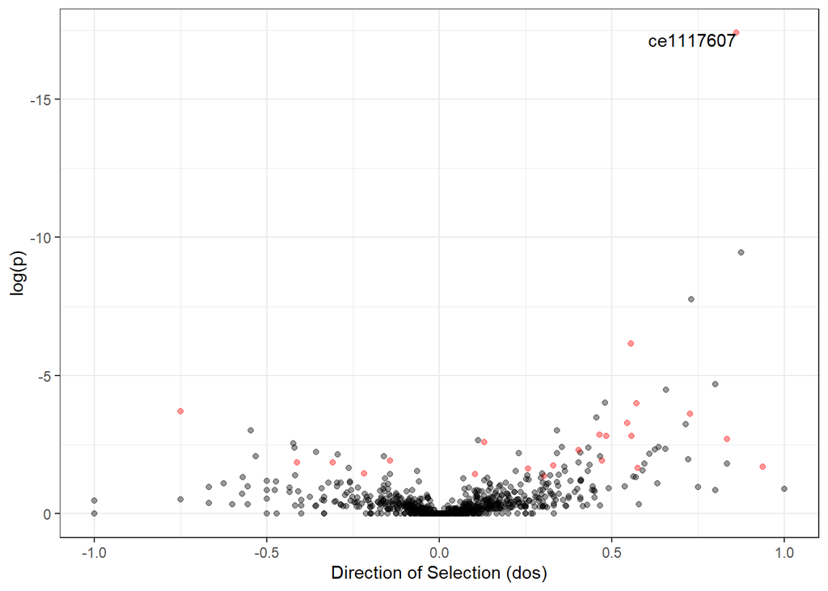

### 4.3.2 Swallow

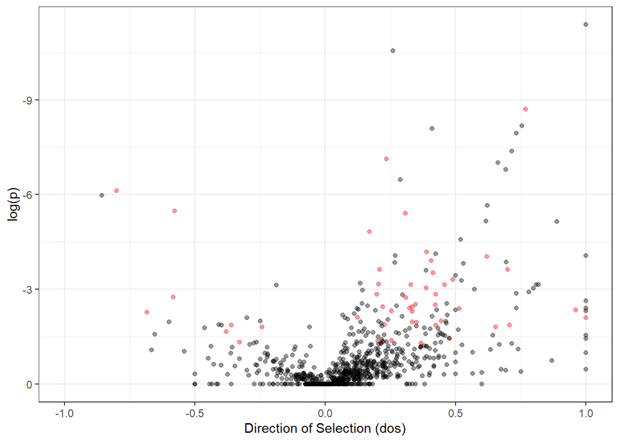

## 4.4 For each gene

We repeated the above approach for each gene by counting up the fixed and polymorphic sites for all conserved elements within 10000 bp of each gene (including those in introns)

```r
#Get list of elements within 10000 bp of each gene using bedtools
bulbul_gene_10000 <- read.table("Bmel_CDS_elements_intersect.txt", sep = "\t", header = F)
bulbul_gene_10000$id <- str_extract(bulbul_gene_10000$V9, "gene_id [A-Za-z0-9-_.]*")
bulbul_gene_10000$id <- gsub("gene_id ", "", bulbul_gene_10000$id)
bulbul_gene_10000$id2 <- gsub(".[0-9]*$", "", bulbul_gene_10000$id)
bulbul_gene_10000$gene <- mapvalues(bulbul_gene_10000$id2, from=ids$t_transcript, to=ids$t_gene, warn_missing = F)

bulbul_mk_table <- read.table("bulbul_noisle_mk.tsv", sep = "\t", header = T)
bulbul_mk_table <- merge(bulbul_mk_table, bulbul_gene_10000[,c("gene", "V13")], by="gene", all.x = F, all.y = F)

bulbul <- read.table("all_accl_bulbul_noisle_stats.txt", sep="\t", header = T)
bulbul_mk_table <- merge(bulbul_mk_table, bulbul, by.x = "V13", by.y="element", all.x = F, all.y = F)
bulbul_mk_table <- unique(bulbul_mk_table)

#remove elements accelerated in sylvia
rate2 <- fread("M2_elem_Z.txt", sep = "\t", header = T, select = c(1,13))
sylv_accl <- phyloacc$original.id[which(phyloacc$best.fit.model %in% c("M1","M2") & phyloacc$phyloacc.id %in% rate2$`Locus ID`[which(rate2$Sylvia_atricapilla == 2)])]

bulbul_mk_table <- subset(bulbul_mk_table, !(V13 %in% sylv_accl))

#get sum of all elements within 10000 bp of each gene
bulbul_gene <- bulbul_mk_table %>% group_by(gene) %>% summarize(fixed = sum(fixed),
                                                                  poly = sum(poly),
                                                                  len = sum(len),
                                                                  dS = first(dS),
                                                                  pS = first(pS),
                                                                  cds_length = first(cds_length),
                                                                  f0 = first(f0),
                                                                  f2 = first(f2),
                                                                  f3 = first(f3),
                                                                  f4 = first(f4))
bulbul_gene$cnee_dos <-  bulbul_gene$fixed / (bulbul_gene$fixed + bulbul_gene$dS) - bulbul_gene$poly / (bulbul_gene$poly + bulbul_gene$pS)
bulbul_gene$alpha <- 1-((bulbul_gene$dS/bulbul_gene$fixed)/(bulbul_gene$pS/bulbul_gene$poly))

bulbul_gene$fisher <- apply(bulbul_gene[, c("pS", "poly", "dS", "fixed")], 1, do_fisher)
bulbul_gene$sig <- ifelse(bulbul_gene$fisher < 0.05, "red", "black")


write.table(bulbul_gene, "bulbul_gene_mk.txt", sep = "\t", row.names = F, col.names = T, quote = F)
```

The above methods were repeated for swallows with elements in Acrocephalus removed.

### 4.4.1 Bulbul

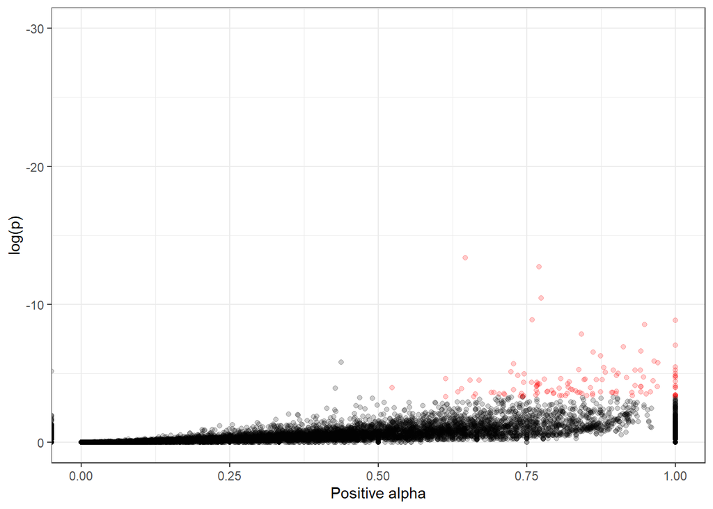

### 4.4.2 Swallow

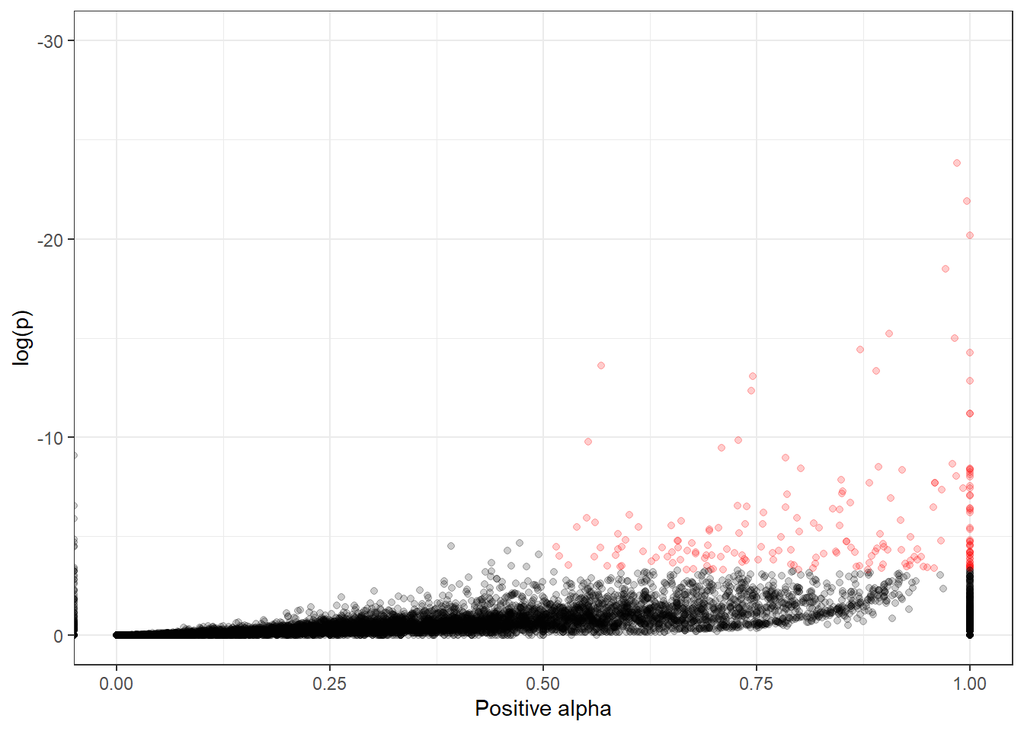

# References

Franco, Arnaud Di, Raphaël Poujol, Denis Baurain, and Hervé Philippe. 2019. “Evaluating the Usefulness of Alignment Filtering Methods to Reduce the Impact of Errors on Evolutionary Inferences.” *BMC Evolutionary Biology* 19 (January): 1–17. https://doi.org/10.1186/S12862-019-1350-2/FIGURES/6.

Kirilenko, Bogdan M, Chetan Munegowda, Ekaterina Osipova, David Jebb, Virag Sharma, Moritz Blumer, Ariadna E Morales, et al. 2023. “Integrating Gene Annotation with Orthology Inference at Scale.” *Science* 380 (6643): eabn3107.

Mirchandani, Cade D., Allison J. Shultz, Gregg W. C. Thomas, Sara J. Smith, Mara Baylis, Brian Arnold, Russ Corbett-Detig, Erik Enbody, and Timothy B. Sackton. 2023. “A Fast, Reproducible, High-Throughput Variant Calling Workflow for Evolutionary, Ecological, and Conservation Genomics.” *bioRxiv*. https://doi.org/10.1101/2023.06.22.546168.

Ranwez, Vincent, Emmanuel JP Douzery, Cédric Cambon, Nathalie Chantret, and Frédéric Delsuc. 2018. “MACSE V2: Toolkit for the Alignment of Coding Sequences Accounting for Frameshifts and Stop Codons.” *Molecular Biology and Evolution* 35 (10): 2582–84.

Safran, Rebecca J, Elizabeth SC Scordato, Matthew R Wilkins, Joanna K Hubbard, Brittany R Jenkins, Tomas Albrecht, SM Flaxman, et al. 2016. “Genome-Wide Differentiation in Closely Related Populations: The Roles of Selection and Geographic Isolation.” *Molecular Ecology* 25 (16): 3865–83.

Shakya, Subir B, Tri Haryoko, Mohammad Irham, Suparno, Dewi M Prawiradilaga, and Frederick H Sheldon. 2021. “Genomic Investigation of Colour Polymorphism and Phylogeographic Variation Among Populations of Black-Headed Bulbul (Brachypodius Atriceps) in Insular Southeast Asia.” *Molecular Ecology* 30 (19): 4757–70.

Smith, Martin D., Joel O. Wertheim, Steven Weaver, Ben Murrell, Konrad Scheffler, and Sergei L. Kosakovsky Pond. 2015. “Less Is More: An Adaptive Branch-Site Random Effects Model for Efficient Detection of Episodic Diversifying Selection.” *Molecular Biology and Evolution* 32 (May): 1342–53. https://doi.org/10.1093/molbev/msv022.